# Predicting Movie Revenue

## Group 7 - Pei-Wen "Steven" Chu, Praveen Jaikant, and Bryce Trezise

## BUDT758X - 0501

## May 10, 2019

### Purpose & Objectives

From low-budget Indie films to star-studded blockbusters, movies come in many different shapes and sizes. Making a movie is a high-risk, high-reward enterprise; one that can take years to come to fruition. Countless hours go into writing the story, casting actors, filming, and editing. Needless to say, undertaking a movie's production is no easy task and requires meticulous planning. Production companies invest a lot of resources into a movie's production. So, a production company needs strong justification to pursue a movie's production. A simple indicator of a potential movie's success is how much revenue it will make.

The goal of our project was to build a linear regression model to predict a potential movie's revenue. We wanted to base our model on a movie’s characteristics such as production budget, genre, and cast information in addition to other information like U.S. economy data and the movie’s release date compared to major U.S. holidays, major sporting events, and season.

### Data

Before building our model and conducting our analysis, we collected data from various sources. We began by brainstorming factors that could affect a movie's ability to generate revenue. In addition to variables directly associated with a movie (like genre, budget, and cast), we wanted to know if external factors could affect revenue. We thought release dates near U.S. holidays and major U.S. sport championships could contribute to a movie's eventual success. We also speculated macroeconomic data like median U.S. household income could affect moviegoers' desire to see a movie.

Our data came from:

- Movie dataset - Kaggle - The Movie Database (TMDB)
- U.S. holidays - Python holidays package
- Big Four (NFL, NHL, MLB, NBA) championship dates - various websites
- Median U.S. household income - U.S. Census Bureau
- U.S. population - Statista
- A-list celebrities - various websites

This jupyter notebook will demonstrate our:

- Data Acquisition & Cleaning
- Data Visualization & Insights
- Regression Results & Analysis

#### Importing the TMDB Dataset

We began by importing the TMDB movies CSV file (Kaggle, 2019). It has a multitude of quantitative and qualitative data points pertaining to movies and the industry as a whole. Unsurprisingly, the data needed a reasonable amount of preprocessing. Several columns (genres, production countries, production companies, cast and crew, etc.) were stored as a string, but were in a dictionary format. So, we developed functions to strip away unnecessary information and only retained data that added value to our dataset. We then cast the data as a dataframe.

```python
path = '/Users/Bryce/Documents/Spring/BUDT758X/Project/Datasets/'
```

```python
import pandas as pd
import numpy as np
import json
import datetime as dt
from datetime import date, datetime
import re
import warnings
warnings.filterwarnings("ignore")
pd.set_option('display.max_columns', 100)
```

Since the Kaggle dataset had both movie and credits datasets with information that we needed, we concatenated the two into a single dataframe.

Both the movies and credits files had fields (genres, production_countries, production_companies, spoken_languages, cast, crew) that were stored as a list of dictionaries in a string format. In order to perform an analysis, we needed to unpack them and create actual dictionaries. To do this, we used json.loads inside a for loop. Json.loads then stripped the string format from each dictionary in the list of dictionaries. Then, each dictionary in the list was reassigned to its initial column in the dataframe, where each value was a dictionary. Each dictionary had two keys - "id" and "name" - regardless of the information (genre, production countries, etc.). Each name value for each type of information had a corresponding ID (but we did not need that information). To strip away the value from each dictionary, we created another function that extracts the value from each name key and converts the values into a comma-separated list. This function was applied to each column that needed to have its dictionaries unpacked and the values extracted. The preprocess function for movies also converted release_date to a datetime format.

```python
def preprocess_movies(movies_file):
    """read movies file and preprocess columns"""
    df = pd.read_csv(movies_file)
    df['release_date'] = pd.to_datetime(df['release_date'])
    dict_columns = ['genres', 'production_countries', 'production_companies', 'spoken_languages']
    for col in dict_columns:
        df[col] = df[col].apply(json.loads)
    return df
```

```python
def preprocess_credits(credits_file):
    """read credits file and preprocess columns"""
    df2 = pd.read_csv(credits_file)
    dict_columns2 = ['cast', 'crew']
    for col2 in dict_columns2:
        df2[col2] = df2[col2].apply(json.loads)
    return df2
```

```python
def get_names(words):
    """split dictionary to get actual value names"""
    return ','.join([x['name'] for x in words])
```

```python
# read in the dataframes and combine movies and credits into one dataframe
movies = preprocess_movies(path + 'tmdb_5000_movies.csv')
credits = preprocess_credits(path + 'tmdb_5000_credits.csv')
df = pd.concat([movies, credits], axis=1)
```

```python
# apply get_names function to extract only 'names' values (genres)
df['genres'] = df['genres'].apply(get_names)
df['genres'].head()
```

```
0    Action,Adventure,Fantasy,Science Fiction
1                    Adventure,Fantasy,Action
2                      Action,Adventure,Crime
3                 Action,Crime,Drama,Thriller
4            Action,Adventure,Science Fiction
Name: genres, dtype: object
```

As we can see, a movie could have more than one genre. In order to reduce the number of categories for our eventual model, we needed to break each genre into a dummy variable. A movie's genre(s) could then be identified one-by-one rather than as a combination.

To create the dummy columns, we iterate through each observation's comma-separated list and split using the split method. This returns a list of genres. We cast this list as a set to retain unique values and re-cast as a list. Finally, we use a for loop to create columns of dummy variables for each genre.

```python
genre_list = []
for s in df['genres'].str.split(','):
    genre_list.extend(s)
genre_list.remove('') # remove blanks
```

```python
genre_list = list(set(genre_list))
genre_list.remove('') # remove blanks
```

```python
for genre_name in genre_list:
    df[genre_name] = df['genres'].str.contains(genre_name).apply(lambda x:1 if x else 0)
```

A movie could be produced in a number of countries. Since there are over 200 countries, we decided to simply use a count for our eventual model. We created a column for the number of countries in which a movie was produced.

```python
df['production_countries'] = df['production_countries'].apply(get_names)
df['production_countries'].head()
df['country_count'] = df.production_countries.apply(lambda s: len(s.split(',')))
```

As with genres and production countries, a movie could have multiple production companies. We wanted to know if a movie was produced by a top production company, which we defined as production companies that produced more than 10 movies in our dataset. So, we created a column with the count of the number of top production companies used in a movie's production. Our dataset had more than 200 observations with "None" for their production company value. Upon inspection using the value_counts method, we found "None" to be the only "production company" with more than 200 movies. So, we exclude "None" from being considered a top production company.

```python
df['production_companies'] = df['production_companies'].apply(get_names)
p_list = []
for a,b in zip(df.production_companies.value_counts(),df.production_companies.value_counts().index):
    if a >10 and a< 200:
        p_list.append(b)
df['top_prod_co']=df.production_companies.map(lambda s: len(set(s.split(',')) & set(p_list)))
```

We wanted to determine if the presence of certain actors and actresses affected a movie's revenue. We later included a list of A-List actors/actresses and created a column to determine how many A-List actors/actresses are in a movie.

```python
df['cast'] = df['cast'].apply(get_names)
```

We found that 99.9% of the movies in our dataset had a status of "released." So, we decided to remove movies that had other statuses (Rumored and Post-production). The results from this action would be negligible to our analysis.

```python
print(df['status'].value_counts())
df = df[df['status'] == 'Released']
```

```
Released           4795
Rumored               5
Post Production       3
Name: status, dtype: int64
```

The median household income dataset only includes years from 1983 to 2016 (U.S. Census Bureau, 2019). Coincidently, most of the movies (92%+) in the dataset were released within this timeframe. Therefore, we limited the movies dataset to this timeframe. Additionally, we realized movie_id and id are identical. We dropped movie_id from our dataframe.

```python
df = df[(df['release_date'].dt.year >= 1983) & (df['release_date'].dt.year < 2017)]
```

```python
df.drop('movie_id', axis=1,inplace=True)
```

```python
df.head()
```

|  | budget | genres | homepage | id | keywords | original_language | original_title | overview | popularity | production_companies | production_countries | release_date | revenue | runtime | spoken_languages | status | tagline | title | vote_average | vote_count | title | cast | crew | TV Movie | War | Adventure | Horror | History | Animation | … |
| --- | --- | --- | --- | --- | --- | --- | --- | --- | --- | --- | --- | --- | --- | --- | --- | --- | --- | --- | --- | --- | --- | --- | --- | --- | --- | --- | --- | --- | --- | --- |
| 0 | 237000000 | Action,Adventure,Fantasy,Science Fiction | http://www.avatarmovie.com/ | 19995 | [{"id": 1463, "name": "culture clash"}, {"id":... | en | Avatar | In the 22nd century, a paraplegic Marine is di... | 150.437577 | Ingenious Film Partners,Twentieth Century Fox ... | United States of America,United Kingdom | 2009-12-10 | 2787965087 | 162.0 | [{'iso_639_1': 'en', 'name': 'English'}, {'iso... | Released | Enter the World of Pandora. | Avatar | 7.2 | 11800 | Avatar | Sam Worthington,Zoe Saldana,Sigourney Weaver,S... | [{'credit_id': '52fe48009251416c750aca23', 'de... | 0 | 0 | 1 | 0 | 0 | 0 | … |
| 1 | 300000000 | Adventure,Fantasy,Action | http://disney.go.com/disneypictures/pirates/ | 285 | [{"id": 270, "name": "ocean"}, {"id": 726, "na... | en | Pirates of the Caribbean: At World's End | Captain Barbossa, long believed to be dead, ha... | 139.082615 | Walt Disney Pictures,Jerry Bruckheimer Films,S... | United States of America | 2007-05-19 | 961000000 | 169.0 | [{'iso_639_1': 'en', 'name': 'English'}] | Released | At the end of the world, the adventure begins. | Pirates of the Caribbean: At World's End | 6.9 | 4500 | Pirates of the Caribbean: At World's End | Johnny Depp,Orlando Bloom,Keira Knightley,Stel... | [{'credit_id': '52fe4232c3a36847f800b579', 'de... | 0 | 0 | 1 | 0 | 0 | 0 | … |
| 2 | 245000000 | Action,Adventure,Crime | http://www.sonypictures.com/movies/spectre/ | 206647 | [{"id": 470, "name": "spy"}, {"id": 818, "name... | en | Spectre | A cryptic message from Bond’s past sends him o... | 107.376788 | Columbia Pictures,Danjaq,B24 | United Kingdom,United States of America | 2015-10-26 | 880674609 | 148.0 | [{'iso_639_1': 'fr', 'name': 'Français'}, {'is... | Released | A Plan No One Escapes | Spectre | 6.3 | 4466 | Spectre | Daniel Craig,Christoph Waltz,Léa Seydoux,Ralph... | [{'credit_id': '54805967c3a36829b5002c41', 'de... | 0 | 0 | 1 | 0 | 0 | 0 | … |
| 3 | 250000000 | Action,Crime,Drama,Thriller | http://www.thedarkknightrises.com/ | 49026 | [{"id": 849, "name": "dc comics"}, {"id": 853,... | en | The Dark Knight Rises | Following the death of District Attorney Harve... | 112.312950 | Legendary Pictures,Warner Bros.,DC Entertainme... | United States of America | 2012-07-16 | 1084939099 | 165.0 | [{'iso_639_1': 'en', 'name': 'English'}] | Released | The Legend Ends | The Dark Knight Rises | 7.6 | 9106 | The Dark Knight Rises | Christian Bale,Michael Caine,Gary Oldman,Anne ... | [{'credit_id': '52fe4781c3a36847f81398c3', 'de... | 0 | 0 | 0 | 0 | 0 | 0 | … |
| 4 | 260000000 | Action,Adventure,Science Fiction | http://movies.disney.com/john-carter | 49529 | [{"id": 818, "name": "based on novel"}, {"id":... | en | John Carter | John Carter is a war-weary, former military ca... | 43.926995 | Walt Disney Pictures | United States of America | 2012-03-07 | 284139100 | 132.0 | [{'iso_639_1': 'en', 'name': 'English'}] | Released | Lost in our world, found in another. | John Carter | 6.1 | 2124 | John Carter | Taylor Kitsch,Lynn Collins,Samantha Morton,Wil... | [{'credit_id': '52fe479ac3a36847f813eaa3', 'de... | 0 | 0 | 1 | 0 | 0 | 0 | … |

### Applying External Data

At this point, we had a large dataframe with many unnecessary columns. So, we created a new dataframe with the columns we would need moving forward. We added external information and built visualizations based on this new dataframe (df_final). The external data came from a number of sources, as mentioned above. We set "id" as the index of this new dataframe. We also impute movies with null runtimes with the average runtime of the movies in our dataset.

Since a lot of our external data used year as an identifying factor, we needed to extract year information for each movie. We also replaced missing revenue with the average revenue of all movies released during the same year as the movie in question.

We placed a lot of significance on the proximity of a movie's release date to that of what we consider to be major events. So, we defined a function that takes inputs of a list of event dates, the name of the new column containing dummy variables, and the number of days the release date should be within (with a default value of 7 days). The function checks if a movie's release data and the event's date is within a timedelta of the specified number of days. This produces a list of timedelta objects if the release date is close to an event date, or an empty list if it is not. The function then checks the length of each list. Then, using a for loop, the function checks if each value is greater than or equal to 2. If true, another list (previously defined as empty) is appended with 1. Otherwise, the list is appended with the length of the timedelta list (which would either be 0 or 1). This list is returned with the specified column name and appended as a column to our dataframe.

NOTE: We exported our dataframe at several points in this notebook. This was so we could import the completed dataframe to our showcase notebook while only showing a few example lines of code in our showcase notebook. We included the exports here to show where the import data originated.

```python
df_final=df.iloc[:,[0,1,3,8,11,12,13,17,18,19,21,*range(23,45)]]
df_final.set_index('id', inplace=True)
df_final.runtime=df_final.runtime.fillna(df_final.runtime.mean())
```

##### Export 1 for Showcase

```python
df_final.to_excel('export1.xlsx')
```

```python
df_final['release_year'] = df_final['release_date'].dt.year
```

```python
non_zero_revenue = df_final['revenue'] != 0
mean_revenue = dict(df_final[non_zero_revenue].groupby('release_year')['revenue'].mean())
df_final.loc[df_final['revenue'] == 0, 'revenue'] = df_final['release_year'].map(mean_revenue)
```

```python
def calculate_difference_count(event_dates,new_col_name,days=7):
    """Checks if an event happened within 7 days (default) and create a column with dummy variables"""
    t1=df_final.release_date.apply(lambda row: [row - a for a in event_dates if ((row- a) <= dt.timedelta(days)) & ((row- a) >= dt.timedelta(-days))])
    t2=[len(a) for a in t1]
    t3 = []
    for a in t2:
        if a >= 2:
            t3.append(1)
        else:
            t3.append(a)
    df_final[new_col_name] = t3
```

#### Household Income

The median household income data collected from the U.S. Census Bureau was stored as an Excel file (U.S. Census Bureau, 2019). After importing the data, we used the map method to add the median household income for the year the movie was released. We did this by creating a dictionary where the keys were year and the values were the median household income for that year. We had to adjust each year by one year because the information was recorded at the end of the year. To make the columns easier to understand, we changed their names and then dropped unnecessary columns.

```python
household_income = pd.read_excel(path + 'Median Housing Income.xls', parse_dates=True)
# create year column with 1 year adjustment since it's recorded at the end of the year
household_income['observation_year'] = household_income['observation_date'].dt.year - 1
household_income['median_income'] = household_income['MEHOINUSA646N']
household_income.drop(['MEHOINUSA646N','observation_date'], axis = 1,inplace=True)
```

```python
income_dict = dict(zip(household_income.observation_year, household_income.median_income))
df_final['median_income'] = df_final['release_year'].map(income_dict)
```

#### Holiday

We used the holidays package in Python to determine the major holidays in the U.S. (Python Software Foundation, 2019) We needed to convert the movie's release date to the correct datetime format in order to match the release date with the holiday dates. We created a dummy variable using the function we created earlier to determine if the movie was released within a week of a major U.S. holiday.

```python
import holidays
```

```python
df_final['release_date'] = df_final['release_date'].apply(lambda x: x.date())
# create a list of release years
release_years = df_final['release_year'].unique()
release_years = [int(year) for year in release_years ]
```

```python
holiday_master = []
for year in release_years:
    key_list = list(holidays.UnitedStates(years=year).keys())
    for key in key_list:
        holiday_master.append(key)
```

```python
calculate_difference_count(holiday_master,'holiday_release')
```

```python
df_final.head()
```

| id | budget | genres | popularity | release_date | revenue | runtime | title | vote_average | vote_count | cast | TV Movie | War | Adventure | Horror | History | Animation | Crime | Romance | Thriller | Family | Science Fiction | Documentary | Foreign | Comedy | Drama | Western | Music | Action | Fantasy | … |
| --- | --- | --- | --- | --- | --- | --- | --- | --- | --- | --- | --- | --- | --- | --- | --- | --- | --- | --- | --- | --- | --- | --- | --- | --- | --- | --- | --- | --- | --- | --- |
| 19995 | 237000000 | Action,Adventure,Fantasy,Science Fiction | 150.437577 | 2009-12-10 | 2.787965e+09 | 162.0 | Avatar | 7.2 | 11800 | Sam Worthington,Zoe Saldana,Sigourney Weaver,S... | 0 | 0 | 1 | 0 | 0 | 0 | 0 | 0 | 0 | 0 | 1 | 0 | 0 | 0 | 0 | 0 | 0 | 1 | 1 | … |
| 285 | 300000000 | Adventure,Fantasy,Action | 139.082615 | 2007-05-19 | 9.610000e+08 | 169.0 | Pirates of the Caribbean: At World's End | 6.9 | 4500 | Johnny Depp,Orlando Bloom,Keira Knightley,Stel... | 0 | 0 | 1 | 0 | 0 | 0 | 0 | 0 | 0 | 0 | 0 | 0 | 0 | 0 | 0 | 0 | 0 | 1 | 1 | … |
| 206647 | 245000000 | Action,Adventure,Crime | 107.376788 | 2015-10-26 | 8.806746e+08 | 148.0 | Spectre | 6.3 | 4466 | Daniel Craig,Christoph Waltz,Léa Seydoux,Ralph... | 0 | 0 | 1 | 0 | 0 | 0 | 1 | 0 | 0 | 0 | 0 | 0 | 0 | 0 | 0 | 0 | 0 | 1 | 0 | … |
| 49026 | 250000000 | Action,Crime,Drama,Thriller | 112.312950 | 2012-07-16 | 1.084939e+09 | 165.0 | The Dark Knight Rises | 7.6 | 9106 | Christian Bale,Michael Caine,Gary Oldman,Anne ... | 0 | 0 | 0 | 0 | 0 | 0 | 1 | 0 | 1 | 0 | 0 | 0 | 0 | 0 | 1 | 0 | 0 | 1 | 0 | … |
| 49529 | 260000000 | Action,Adventure,Science Fiction | 43.926995 | 2012-03-07 | 2.841391e+08 | 132.0 | John Carter | 6.1 | 2124 | Taylor Kitsch,Lynn Collins,Samantha Morton,Wil... | 0 | 0 | 1 | 0 | 0 | 0 | 0 | 0 | 0 | 0 | 1 | 0 | 0 | 0 | 0 | 0 | 0 | 1 | 0 | … |

#### Sports

Similar to our holiday logic, we determined dummy variables for the championships of the Big 4 Major League sports in the U.S. (NFL, NHL, NBA, and MLB). We acquired the data from multiple websites, with the process being similar for each sport.

##### Super Bowl Dates

After scraping the data from the website, we changed the DATE column into the necessary datetime format (ESPN, 2019). We created a list with the dates of all Super Bowls. Then, we applied our function to create dummy variables.

```python
# read website to acquire data
super_bowls = pd.read_html('http://www.espn.com/nfl/superbowl/history/winners?fbclid=IwAR372lHu_rAAhOGeeyEihLVwK_kwnpsRLHIdLSVJQ3-Z1RErOH7Z1pnjOeg', index_col = 0, header = 1)[0]
super_bowls.head()
```

| NO. | DATE | SITE | RESULT |
| --- | --- | --- | --- |
| I | Jan. 15, 1967 | Los Angeles Memorial Coliseum | Green Bay 35, Kansas City 10 |
| II | Jan. 14, 1968 | Orange Bowl (Miami) | Green Bay 33, Oakland 14 |
| III | Jan. 12, 1969 | Orange Bowl (Miami) | New York Jets 16, Baltimore 7 |
| IV | Jan. 11, 1970 | Tulane Stadium (New Orleans) | Kansas City 23, Minnesota 7 |
| V | Jan. 17, 1971 | Orange Bowl (Miami) | Baltimore 16, Dallas 13 |

```python
# date to correct format
super_bowls['DATE'] = super_bowls['DATE'].apply(lambda x: datetime.strptime(x, '%b. %d, %Y').date())
super_bowl_dates = list(super_bowls['DATE'])
```

```python
calculate_difference_count(super_bowl_dates,'superbowl_release')
```

##### Stanley Cup Playoffs Dates

We had to run our pandas read_html function through a for loop to scrape the Stanley Cup Playoffs dates (Hockey Reference, 2019). Since the dates were read in as a string, we needed to perform additional preprocessing in order to get the dates and years into a format that we could parse. Then, we created a list similar to that performed for the Super Bowl dates. We applied our function and created a column with dummy variables.

```python
stanley_cup_dates = []
for year in release_years:
    # no Stanley Cup in 2005 due to workers strike
    if year != 2005:
        url = 'https://www.hockey-reference.com/playoffs/NHL_' + str(year) + '.html'
        cup_year = pd.read_html(url, skiprows = 2, index_col = 1)[0]
        cup_list = list(cup_year.index)
        for date in cup_list:
            if type(date) == str:
                stanley_cup_dates.append(date + ', ' + str(year))
            else:
                break
```

```python
stanley_cup_dates_fixed = []
for date in stanley_cup_dates:
    date_fix = datetime.strptime(date, '%B %d, %Y').date()
    stanley_cup_dates_fixed.append(date_fix)
```

```python
calculate_difference_count(stanley_cup_dates_fixed,'stanley_cup_release')
```

##### NBA Finals Dates

Similar to the Stanley Cup Playoffs dates, we had to use a for loop to scrape our NBA Finals data and convert it to a form that we could parse (Wikipedia, 2019). We then created a list of dates similar to those for Super Bowl and Stanley Cup Playoff dates and applied our function to create a column of dummy variables.

```python
nba_game_list = []
for i in release_years:
    nba_finals_data = pd.read_html('https://en.wikipedia.org/wiki/' + str(i) +'_NBA_Finals', match = 'Home', header = 0)[0]
    datestr = nba_finals_data.Date + ', ' + str(i)
    for i in range(len(datestr)):
        try:
            date_game = datetime.strptime(datestr[i], '%A, %B %d, %Y')
            nba_game_list.append(datetime.date(date_game))
            nba_game_year = date_game.year
        except ValueError:
            pass
```

```python
calculate_difference_count(nba_game_list,'nba_release')
```

##### MLB World Series Dates

The MLB World Series dates were more difficult to process (Baseball Reference, 2019). We had to use a for loop to scrape the data. The dates were contained within a string. So, we used regular expressions to extract the dates. The dates were in a nested list. We had to flatten it to make it consistent with our other date parsing processes. We then parsed the dates into the necessary datetime format. We applied our function to create a column of dummy variables.

```python
mlb_world_series = []
for year in release_years:
    url='https://www.baseball-reference.com/postseason/' + str(year) +'_WS.shtml'
    if year != 1994:
        world_series = pd.read_html(url)
        list_tmp = re.findall('Game \d+\, ([A-Z][a-z]* \d*)', str(world_series))
        list_tmp2 = []
        for b in list_tmp:
            list_tmp2.append(b +', '+ str(year))
        mlb_world_series.append(list_tmp2)
# flatten list - originally read as a list of lists
flat_list_ws = [item for sublist in mlb_world_series for item in sublist]
```

```python
mlb_world_series_dates = []
for date in flat_list_ws:
    date_fix = datetime.strptime(date, '%B %d, %Y')
    mlb_world_series_dates.append(datetime.date(date_fix))
```

```python
calculate_difference_count(mlb_world_series_dates,'world_series_release')
```

```python
df_final.head()
```

| id | budget | genres | popularity | release_date | revenue | runtime | title | vote_average | vote_count | cast | TV Movie | War | Adventure | Horror | History | Animation | Crime | Romance | Thriller | Family | Science Fiction | Documentary | Foreign | Comedy | Drama | Western | Music | Action | Fantasy | … |
| --- | --- | --- | --- | --- | --- | --- | --- | --- | --- | --- | --- | --- | --- | --- | --- | --- | --- | --- | --- | --- | --- | --- | --- | --- | --- | --- | --- | --- | --- | --- |
| 19995 | 237000000 | Action,Adventure,Fantasy,Science Fiction | 150.437577 | 2009-12-10 | 2.787965e+09 | 162.0 | Avatar | 7.2 | 11800 | Sam Worthington,Zoe Saldana,Sigourney Weaver,S... | 0 | 0 | 1 | 0 | 0 | 0 | 0 | 0 | 0 | 0 | 1 | 0 | 0 | 0 | 0 | 0 | 0 | 1 | 1 | … |
| 285 | 300000000 | Adventure,Fantasy,Action | 139.082615 | 2007-05-19 | 9.610000e+08 | 169.0 | Pirates of the Caribbean: At World's End | 6.9 | 4500 | Johnny Depp,Orlando Bloom,Keira Knightley,Stel... | 0 | 0 | 1 | 0 | 0 | 0 | 0 | 0 | 0 | 0 | 0 | 0 | 0 | 0 | 0 | 0 | 0 | 1 | 1 | … |
| 206647 | 245000000 | Action,Adventure,Crime | 107.376788 | 2015-10-26 | 8.806746e+08 | 148.0 | Spectre | 6.3 | 4466 | Daniel Craig,Christoph Waltz,Léa Seydoux,Ralph... | 0 | 0 | 1 | 0 | 0 | 0 | 1 | 0 | 0 | 0 | 0 | 0 | 0 | 0 | 0 | 0 | 0 | 1 | 0 | … |
| 49026 | 250000000 | Action,Crime,Drama,Thriller | 112.312950 | 2012-07-16 | 1.084939e+09 | 165.0 | The Dark Knight Rises | 7.6 | 9106 | Christian Bale,Michael Caine,Gary Oldman,Anne ... | 0 | 0 | 0 | 0 | 0 | 0 | 1 | 0 | 1 | 0 | 0 | 0 | 0 | 0 | 1 | 0 | 0 | 1 | 0 | … |
| 49529 | 260000000 | Action,Adventure,Science Fiction | 43.926995 | 2012-03-07 | 2.841391e+08 | 132.0 | John Carter | 6.1 | 2124 | Taylor Kitsch,Lynn Collins,Samantha Morton,Wil... | 0 | 0 | 1 | 0 | 0 | 0 | 0 | 0 | 0 | 0 | 1 | 0 | 0 | 0 | 0 | 0 | 0 | 1 | 0 | … |

#### Blockbuster

We wanted to see how a movie's release date that was close to a blockbuster affected its revenue. We defined blockbuster movies to be movies that had revenue greater than $500 million. We created a column to determine if a movie was, by our definition, considered a blockbuster. Similar to the sporting dates lists, we then created a list of blockbuster release dates. We applied our function to create a column of dummy variables that determines if a movie was released within a specified number of days (in this case, 7 days) of a blockbuster movie's release date.

```python
df_final['blockbuster'] = np.where(df_final.revenue > 500000000, 1, 0)
blockbuster_date = []
for a in df_final[df_final.blockbuster == 1].release_date:
    blockbuster_date.append(a)
```

```python
calculate_difference_count(blockbuster_date,'blockbuster_date')
```

#### U.S. Population

We gathered U.S. population data from statista as an Excel file (statista, 2019). After loading the Excel, we created a dictionary that used year for the keys and the population for each year as the values. We mapped this dictionary to our dataframe to give us a new column with the U.S. population in the year each movie was released.

```python
population_data = pd.read_excel(path + 'US Population.xlsx', header = 1)
```

```python
population_dict = dict(zip(population_data.Year, population_data['Number of residents (in thousands)']))
df_final['population in thousands'] = df_final['release_year'].map(population_dict)
df_final[['release_year','population in thousands']].head()
```

| id | release_year | population in thousands |
| --- | --- | --- |
| 19995 | 2009 | 307007.00 |
| 285 | 2007 | 301580.00 |
| 206647 | 2015 | 320742.67 |
| 49026 | 2012 | 313874.22 |
| 49529 | 2012 | 313874.22 |

#### Seasons

We wanted to see how the season a movie was released affected the movie's revenue. We defined a function that determines the day of the year (January 1 is 1, December 31 is 365). It uses that day of the year to compare an inputted day of the year (in this case, a movie's day of release) and determines the season the movie was released. Spring is considered from days 59 to 150. Summer is considered from days 151 to 242. Fall is considered from days 243 to 333. Winter is considered all other days. We then mapped this function to the day of release for each movie, which we created in a column from the movie's release date.

```python
def season(x):
    spring = range(59, 150) # spring starts from March, goes on until May end
    summer = range(151, 242) # summer starts from June, goes on until August end
    fall = range(243, 333) # fall starts from September, goes on until November end
    if x in spring:
       return 'Spring'
    if x in summer:
       return 'Summer'
    if x in fall:
       return 'Fall'
    else:
       return 'Winter'
```

```python
df_final['day_of_release'] = pd.to_datetime(df_final['release_date']).dt.dayofyear
df_final['season'] = df_final.day_of_release.map(season)
```

```python
df_final[['release_date','day_of_release','season']].head()
```

| id | release_date | day_of_release | season |
| --- | --- | --- | --- |
| 19995 | 2009-12-10 | 344 | Winter |
| 285 | 2007-05-19 | 139 | Spring |
| 206647 | 2015-10-26 | 299 | Fall |
| 49026 | 2012-07-16 | 198 | Summer |
| 49529 | 2012-03-07 | 67 | Spring |

#### A-List Actors & Actresses

As mentioned above, we wanted to determine if a movie's revenue was affected by an actor's or actress's presence. We determined this by creating a list of A-List actors and actresses. We retrieved this data by scraping from two websites. For the first, we had to strip away text to extract the actors' and actresses' names (Ultimate Movie Rankings, 2019). We appended these extracted names to a list. The second site required us to us a for loop, but the data was extracted as a list of lists (The Richest, 2019). We flattened this list of lists and extended the list we created for the first site. We cast the list of A-List actors and actresses as a set to retain unique values (191). We mapped a lambda function to the cast column that finds common values between a movie's cast list and the A-List actors and actresses list. The result is a set. The lambda function then checks the length of that set in order to determine how many A-List actors and actresses are in the movie. These values are stored in a new column.

```python
a_list = pd.read_html('https://www.ultimatemovierankings.com/top-100-movie-stars/', match='Career Adjusted Box Office')[0]
```

```python
a_list['Actor/Actress'] = a_list['Actor/Actress'].map(lambda x: x.strip('Actor '))
a_list['Actor/Actress'] = a_list['Actor/Actress'].map(lambda x: x.strip('Actress '))
final_a_list = list(a_list['Actor/Actress'])
```

```python
b=[]
for i in range(4):
    a = pd.read_html('https://www.therichest.com/top-lists/top-100-richest-actors/page/' + str(i+1) +'/')
    b.append(list(a[0]['Name']))
a_flattened_list = [y for x in b for y in x]
final_a_list.extend(a_flattened_list)
final_a_list = set(list(final_a_list))
```

```python
df_final['a_list_count'] = df_final['cast'].map(lambda x: len(set(x.split(',')) & set(final_a_list)))
df.head()
```

|  | budget | genres | homepage | id | keywords | original_language | original_title | overview | popularity | production_companies | production_countries | release_date | revenue | runtime | spoken_languages | status | tagline | title | vote_average | vote_count | title | cast | crew | TV Movie | War | Adventure | Horror | History | Animation | … |
| --- | --- | --- | --- | --- | --- | --- | --- | --- | --- | --- | --- | --- | --- | --- | --- | --- | --- | --- | --- | --- | --- | --- | --- | --- | --- | --- | --- | --- | --- | --- |
| 0 | 237000000 | Action,Adventure,Fantasy,Science Fiction | http://www.avatarmovie.com/ | 19995 | [{"id": 1463, "name": "culture clash"}, {"id":... | en | Avatar | In the 22nd century, a paraplegic Marine is di... | 150.437577 | Ingenious Film Partners,Twentieth Century Fox ... | United States of America,United Kingdom | 2009-12-10 | 2787965087 | 162.0 | [{'iso_639_1': 'en', 'name': 'English'}, {'iso... | Released | Enter the World of Pandora. | Avatar | 7.2 | 11800 | Avatar | Sam Worthington,Zoe Saldana,Sigourney Weaver,S... | [{'credit_id': '52fe48009251416c750aca23', 'de... | 0 | 0 | 1 | 0 | 0 | 0 | … |
| 1 | 300000000 | Adventure,Fantasy,Action | http://disney.go.com/disneypictures/pirates/ | 285 | [{"id": 270, "name": "ocean"}, {"id": 726, "na... | en | Pirates of the Caribbean: At World's End | Captain Barbossa, long believed to be dead, ha... | 139.082615 | Walt Disney Pictures,Jerry Bruckheimer Films,S... | United States of America | 2007-05-19 | 961000000 | 169.0 | [{'iso_639_1': 'en', 'name': 'English'}] | Released | At the end of the world, the adventure begins. | Pirates of the Caribbean: At World's End | 6.9 | 4500 | Pirates of the Caribbean: At World's End | Johnny Depp,Orlando Bloom,Keira Knightley,Stel... | [{'credit_id': '52fe4232c3a36847f800b579', 'de... | 0 | 0 | 1 | 0 | 0 | 0 | … |
| 2 | 245000000 | Action,Adventure,Crime | http://www.sonypictures.com/movies/spectre/ | 206647 | [{"id": 470, "name": "spy"}, {"id": 818, "name... | en | Spectre | A cryptic message from Bond’s past sends him o... | 107.376788 | Columbia Pictures,Danjaq,B24 | United Kingdom,United States of America | 2015-10-26 | 880674609 | 148.0 | [{'iso_639_1': 'fr', 'name': 'Français'}, {'is... | Released | A Plan No One Escapes | Spectre | 6.3 | 4466 | Spectre | Daniel Craig,Christoph Waltz,Léa Seydoux,Ralph... | [{'credit_id': '54805967c3a36829b5002c41', 'de... | 0 | 0 | 1 | 0 | 0 | 0 | … |
| 3 | 250000000 | Action,Crime,Drama,Thriller | http://www.thedarkknightrises.com/ | 49026 | [{"id": 849, "name": "dc comics"}, {"id": 853,... | en | The Dark Knight Rises | Following the death of District Attorney Harve... | 112.312950 | Legendary Pictures,Warner Bros.,DC Entertainme... | United States of America | 2012-07-16 | 1084939099 | 165.0 | [{'iso_639_1': 'en', 'name': 'English'}] | Released | The Legend Ends | The Dark Knight Rises | 7.6 | 9106 | The Dark Knight Rises | Christian Bale,Michael Caine,Gary Oldman,Anne ... | [{'credit_id': '52fe4781c3a36847f81398c3', 'de... | 0 | 0 | 0 | 0 | 0 | 0 | … |
| 4 | 260000000 | Action,Adventure,Science Fiction | http://movies.disney.com/john-carter | 49529 | [{"id": 818, "name": "based on novel"}, {"id":... | en | John Carter | John Carter is a war-weary, former military ca... | 43.926995 | Walt Disney Pictures | United States of America | 2012-03-07 | 284139100 | 132.0 | [{'iso_639_1': 'en', 'name': 'English'}] | Released | Lost in our world, found in another. | John Carter | 6.1 | 2124 | John Carter | Taylor Kitsch,Lynn Collins,Samantha Morton,Wil... | [{'credit_id': '52fe479ac3a36847f813eaa3', 'de... | 0 | 0 | 1 | 0 | 0 | 0 | … |

###### Export 2 for Showcase

```python
df_final.to_excel('export2.xlsx')
```

### Data Visualization & Insights

Before building our regression, we wanted to see what factors, both internal and external, affect a movie's revenue. So, we visualized our data using Python's matplotlib and Seaborn packages. We wanted to answer the following questions using data visualizations to support our answers:

- What general trends do we see for revenue and budget for our dataset's timeframe?
- What is the distribution of revenue within each genre?
- How have the number of movies changed over time per genre?
- Does release near a sporting event affect a movie's revenue?
- Does the season in which a movie is released affect its revenue?
- Does a movie's genre affect revenue?
- Do movies of a certain genre generate higher revenue during different seasons?
- Do movies released around holidays affect revenue?
- Does inclusion of A-List actors/actresses increase revenue?
- Do top production companies using higher budgets result in more blockbusters?

We chose to use line plots to visualize time series data, boxplots for distributions, barplots and point plots for numeric vs. categorical data, and heatmaps for categorical vs. categorical vs. numeric data.

```python
import matplotlib.pyplot as plt
import matplotlib.style
import matplotlib as mpl
import seaborn as sns
import matplotlib.gridspec as gridspec
%matplotlib inline
plt.rcParams['figure.figsize'] = 20, 10
sns.set_style('whitegrid')
```

#### What general trends do we see for revenue and budget for our dataset's timeframe?

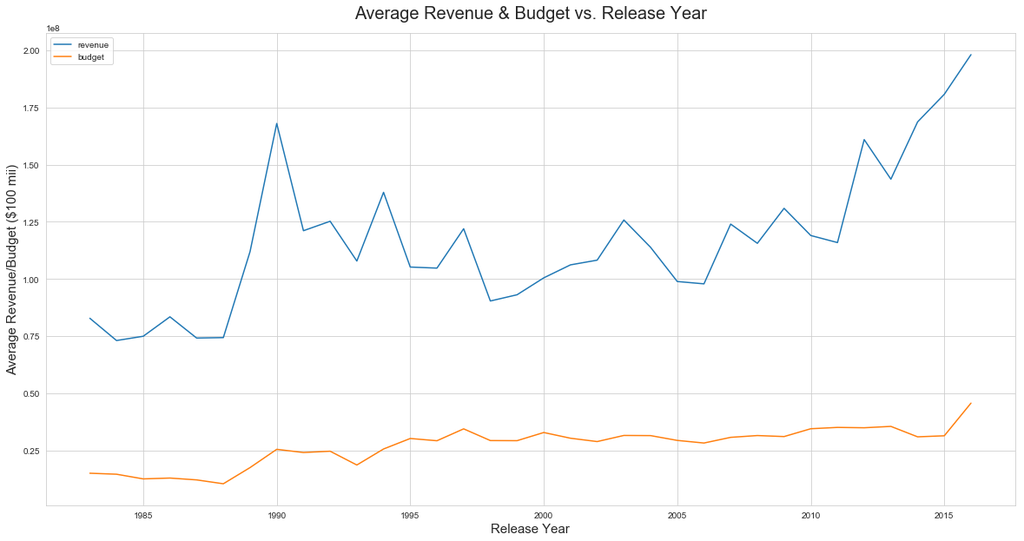

```python
df_final.groupby('release_year')['revenue','budget'].agg('mean').plot();
plt.title('Average Revenue & Budget vs. Release Year', fontsize = 20, y = 1.02);
plt.ylabel('Average Revenue/Budget ($100 mii)', fontsize = 15);
plt.xlabel('Release Year', fontsize = 15);
```

#### What is the distribution of revenue within each genre?

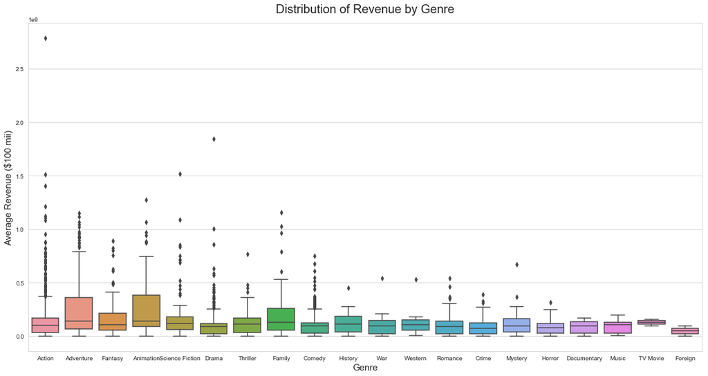

```python
df_final['genre_boxplot']=df_final.genres.str.extract('(\w*\s?\w*)[,]')
sns.boxplot(df_final.genre_boxplot,df_final.revenue);
plt.title('Distribution of Revenue by Genre', fontsize = 20, y = 1.02);
plt.ylabel('Average Revenue ($100 mii)', fontsize = 15);
plt.xlabel('Genre', fontsize = 15);
```

These boxplots display the distribution of revenue per genre. For only this graphic, we considered the first genre for a movie list as the primary genre. Here, we considered genre as hierarchical, where the first genre listed is the primary genre and all subsequent genres are secondary. We can see there are outliers for many genres. This is especially true for Action and Drama, where there are several outliers that generated much more revenue than other movies of the same genre.

#### How have the number of movies changed over time per genre?

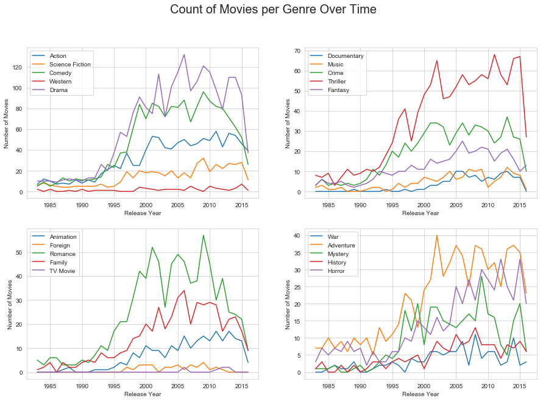

```python
fig, ax = plt.subplots(2, 2, figsize=(15,10));

fig.suptitle('Count of Movies per Genre Over Time', fontsize = 20);
gs1 = gridspec.GridSpec(1, 2);
gs1.tight_layout(fig, rect=[0, 0.03, 1, 0.95]);

df_final.groupby('release_year')['Action','Science Fiction','Comedy','Western','Drama'].agg('sum').plot(ax=ax[0,0]);
df_final.groupby('release_year')['Documentary','Music','Crime','Thriller','Fantasy'].agg('sum').plot(ax=ax[0,1]);
df_final.groupby('release_year')['Animation','Foreign','Romance','Family','TV Movie'].agg('sum').plot(ax=ax[1,0]);
df_final.groupby('release_year')['War','Adventure','Mystery','History','Horror'].agg('sum').plot(ax=ax[1,1]);

# Adjust figure labels

ax[0,0].set_ylabel('Number of Movies');
ax[0,0].set_xlabel('Release Year');

ax[0,1].set_ylabel('Number of Movies');
ax[0,1].set_xlabel('Release Year');

ax[1,0].set_ylabel('Number of Movies');
ax[1,0].set_xlabel('Release Year');

ax[1,1].set_ylabel('Number of Movies');
ax[1,1].set_xlabel('Release Year');
```

As we can see in the subplots above, the number of movies released for all genres appear to have spiked around 1995. The genres that released the most movies since 1995 are Drama, Comedy, and Thriller. Since 2015, most genres have started to release fewer movies.

NOTE: We chose to plot the count of movies per genre over time on 4 subplots in order to make each genre's line easier to read. We recognize this could lead to misleading charts since the y-axes are different and the plots have relatively similar shapes. We want to emphasize that we chose to do this to declutter our plots and make our data easier to see.

#### Does release near a sporting event affect a movie's revenue?

[figure not shown]

```python
fig, ax = plt.subplots(2, 2, figsize=(15,10));

fig.suptitle('Effect of Sporting Events on Movie Revenue', fontsize = 20);
gs1 = gridspec.GridSpec(1, 2);
gs1.tight_layout(fig, rect=[0, 0.03, 1, 0.95]);

df_final.groupby(['stanley_cup_release'])['revenue'].agg('mean').plot(kind='bar', ax=ax[0,0]);
df_final.groupby(['nba_release'])['revenue'].agg('mean').plot(kind='bar', ax=ax[0,1]);
df_final.groupby(['world_series_release'])['revenue'].agg('mean').plot(kind='bar', ax=ax[1,0]);
df_final.groupby(['superbowl_release'])['revenue'].agg('mean').plot(kind='bar', ax=ax[1,1]);

# Adjust figure labels

ax[0,0].set_ylabel('Average Revenue ($100 mil)');
ax[0,0].set_xlabel('Movie Released Within 1 Week of Super Bowl (1 = Yes)');
ax[0,0].set_title('Proximity to the Super Bowl Effect on Revenue');
ax[0,0].set_xticklabels([0,1]);

ax[0,1].set_ylabel('Average Revenue ($100 mil)');
ax[0,1].set_xlabel('Movie Released Within 1 Week of Stanley Cup (1 = Yes)');
ax[0,1].set_title('Proximity to the Stanley Cup Effect on Revenue');
ax[0,1].set_xticklabels([0,1]);

ax[1,0].set_ylabel('Average Revenue ($100 mil)');
ax[1,0].set_xlabel('Movie Released Within 1 Week of World Series (1 = Yes)');
ax[1,0].set_title('Proximity to the World Series Effect on Revenue');
ax[1,0].set_xticklabels([0,1]);

ax[1,1].set_ylabel('Average Revenue ($100 mil)');
ax[1,1].set_xlabel('Movie Released Within 1 Week of NBA Finals (1 = Yes)');
ax[1,1].set_title('Proximity to the NBA Finals Effect on Revenue');
ax[1,1].set_xticklabels([0,1]);
```

#### Does the season in which a movie is released affect its revenue?

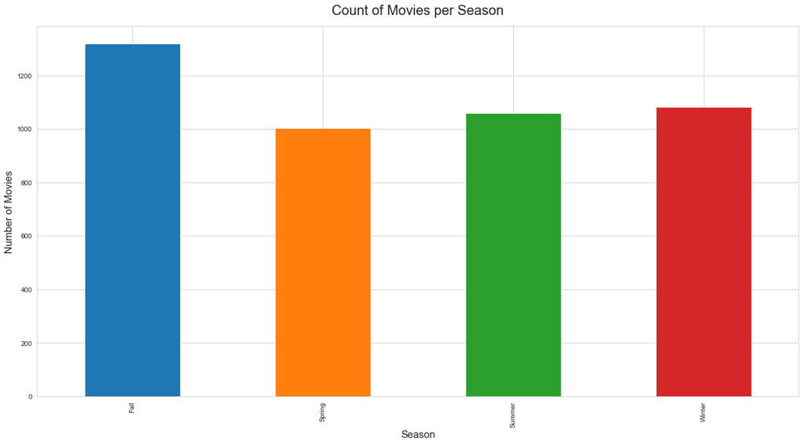

```python
df_final.groupby(['season'])['season'].agg('count').plot(kind='bar');
plt.title('Count of Movies per Season', fontsize = 20, y = 1.02);
plt.xlabel('Season', fontsize = 15);
plt.ylabel('Number of Movies', fontsize = 15);
```

Fall sees more movies released than other seasons, whereas Spring sees fewer movies released. Spring, Summer, and Winter have had around 1,000 movies released in each season. Fall has had more than 1,200.

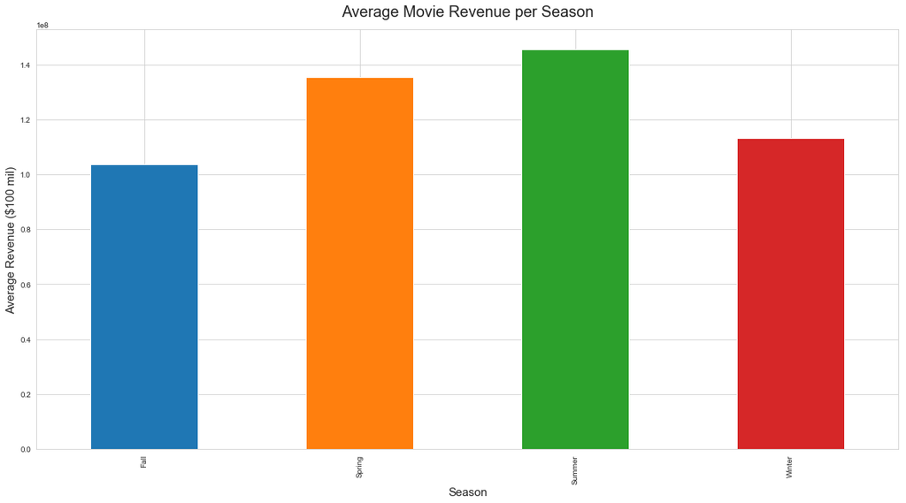

```python
df_final.groupby(['season'])['revenue'].agg('mean').plot(kind='bar');
plt.title('Average Movie Revenue per Season', fontsize = 20, y = 1.02);
plt.xlabel('Season', fontsize = 15);
plt.ylabel('Average Revenue ($100 mil)', fontsize = 15);
```

Here, we see that movies released in Summer, on average, generate the most revenue and movies released in Fall, on average, generate the least revenue. Using the information provided in the last graph, we speculate that this could be caused by supply and demand effects. Since there are more movies released in Fall, audiences have more options from which to choose, thus resulting in lower revenue for movies released in Fall. However, using this logic, we would expect to see Spring generating the most revenue, but this is not the case. Spring is second to Summer.

#### Does a movie's genre affect revenue?

```python
avg_revenue = []
for genre in genre_list:
    avg_revenue.append(int(df_final[df_final[genre]==1].revenue.mean()))
df_genre = pd.DataFrame({'Genre':genre_list,'Avg. Revenue':avg_revenue})
df_genre.sort_values(by='Avg. Revenue',ascending=False,inplace=True)
```

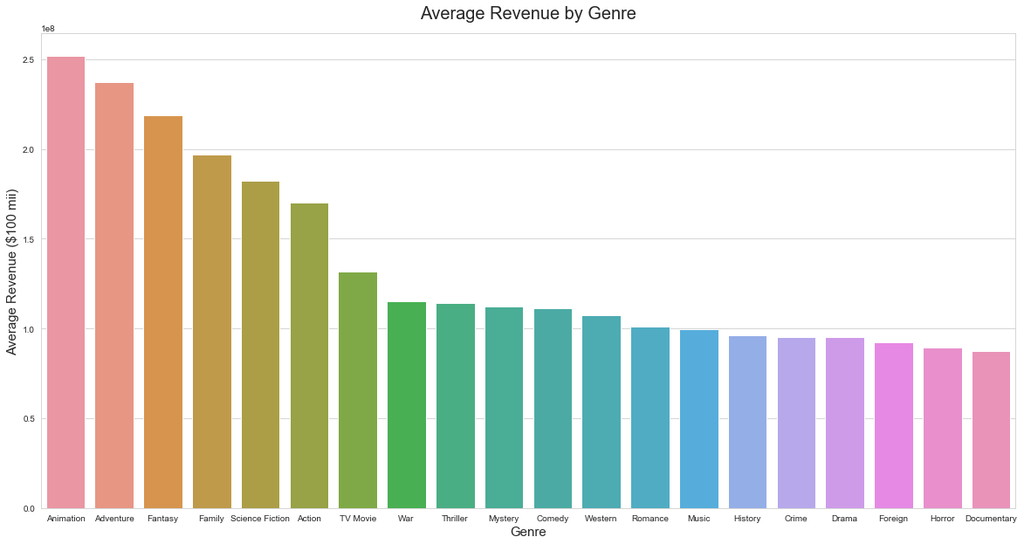

```python
sns.barplot(x="Genre", y="Avg. Revenue", data=df_genre);
plt.title('Average Revenue by Genre', fontsize = 20, y = 1.02);
plt.ylabel('Average Revenue ($100 mii)', fontsize = 15);
plt.xlabel('Genre', fontsize = 15);
```

We can see that genre does affect revenue, but some more than others. For example, animation, adventure, and fantasy movies result in higher average revenue, while documentaries, horror films, and foreign films result in lower average revenues.

#### Do movies of a certain genre generate higher revenue during different seasons?

```python
rev_df2 = pd.DataFrame()
row_of_list = []
for genre in genre_list:
    a = df_final[['season','revenue']].where(df_final['genres'].str.contains(genre))
    a['genre'] = genre
    a.dropna(inplace=True)
    rev_df2 = pd.concat([rev_df2, a], axis=0)
```

```python
rev_df3 = rev_df2.groupby(['season','genre'])['revenue'].mean().unstack()
rev_df4 = rev_df3.loc[['Spring','Summer','Fall','Winter']]
rev_df4 = rev_df4[['Science Fiction','Action','Family','Fantasy','Animation','Adventure']]
```

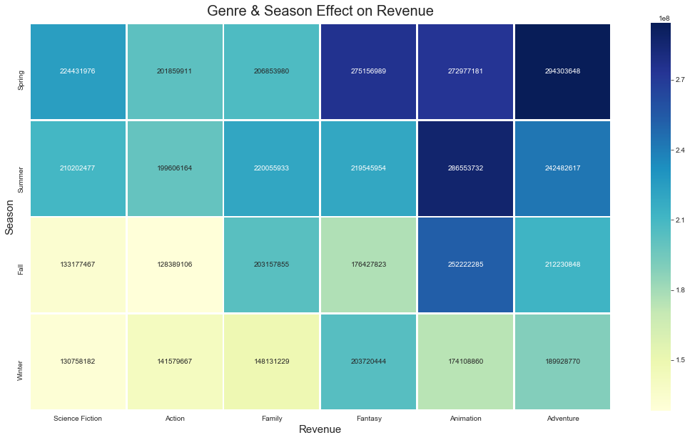

```python
sns.heatmap(rev_df4, cmap='YlGnBu', annot=True, square=True, linewidths=2, fmt='.0f');
plt.title('Genre & Season Effect on Revenue', fontsize = 20, pad = 10);
plt.xlabel('Revenue', fontsize = 15);
plt.ylabel('Season', fontsize = 15);
```

We decided to further explore the genres that result in the top 6 (average revenue drops significantly after 6) highest average revenue. From the above heatmap, we can see that Adventure movies released in the spring and Animation movies released in the summer generate the most revenue. Action movies in the fall and Sci-Fi movies in the winter generate lower revenue.

```python
best_genres = ['Adventure','Animation']
best_seasons = ['Summer','Spring']
df_movie = pd.DataFrame()
df_movie_season = pd.DataFrame()
row_of_list = []
for genre in best_genres:
    a = df_final[['title','season','revenue']].where(df_final['genres'].str.contains(genre))
    a['genre']=genre
    a.dropna(inplace=True)
    df_movie = pd.concat([df_movie, a], axis=0)
for season in best_seasons:
    f = df_movie.where(df_final['season'].str.contains(season))
    f.dropna(inplace=True)
    df_movie_season = pd.concat([df_movie_season, f], axis=0)
df_grouped = df_movie_season.sort_values('revenue',ascending=False).groupby(['genre','season'])
```

```python
df_grouped.get_group(('Adventure','Spring')).head()
```

| id | title | season | revenue | genre |
| --- | --- | --- | --- | --- |
| 24428 | The Avengers | Spring | 1.519558e+09 | Adventure |
| 99861 | Avengers: Age of Ultron | Spring | 1.405404e+09 | Adventure |
| 68721 | Iron Man 3 | Spring | 1.215440e+09 | Adventure |
| 271110 | Captain America: Civil War | Spring | 1.153304e+09 | Adventure |
| 1865 | Pirates of the Caribbean: On Stranger Tides | Spring | 1.045714e+09 | Adventure |

```python
df_grouped.get_group(('Animation','Summer')).head()
```

| id | title | season | revenue | genre |
| --- | --- | --- | --- | --- |
| 211672 | Minions | Summer | 1.156731e+09 | Animation |
| 10193 | Toy Story 3 | Summer | 1.066970e+09 | Animation |
| 93456 | Despicable Me 2 | Summer | 9.707619e+08 | Animation |
| 8355 | Ice Age: Dawn of the Dinosaurs | Summer | 8.866868e+08 | Animation |
| 57800 | Ice Age: Continental Drift | Summer | 8.772448e+08 | Animation |

The two dataframes above provide examples for the movies with the highest revenue in their respective genres during the season where that genre generates the most revenue. The top 4 highest revenue adventure films released in the spring are all Marvel films. The fifth is a Pirates of the Caribbean film. 2 of the 5 animation movies with the highest revenue released in the summer belong to Universal, 2 belong to Fox, and one to Disney. It is unsurprising that massive film studios have created movies with such high revenue. This is probably due to the extensive domain knowledge, movie quality, and brand they have built over multiple decades.

#### Do movies released around holidays make a difference to revenue?

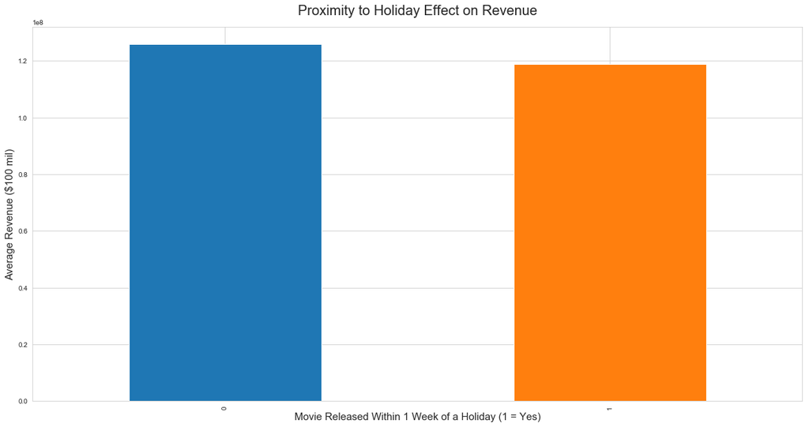

```python
df_final.groupby(['holiday_release'])['revenue'].agg('mean').plot(kind='bar');
plt.title('Proximity to Holiday Effect on Revenue', fontsize = 20, y = 1.02);
plt.xlabel('Movie Released Within 1 Week of a Holiday (1 = Yes)', fontsize = 15);
plt.ylabel('Average Revenue ($100 mil)', fontsize = 15);
```

As we can see from the barplot above, movies released within one week of a major U.S. holiday earn slightly less revenue, on average, than other movies. This is surprising to us. We speculated that movies released within close proximity to a holiday would earn higher revenue. Perhaps this would be true for opening weekend revenue, but that is not the target of our analysis (overall revenue is our target).

#### Does inclusion of A-List actors/actresses increase revenue?

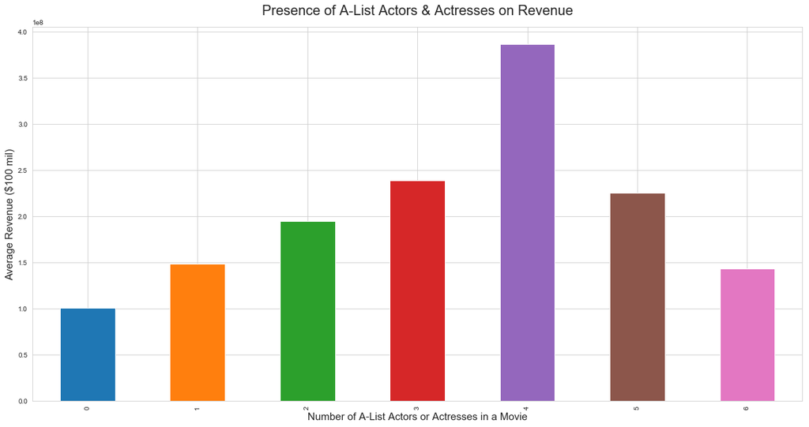

```python
df_final.groupby(['a_list_count'])['revenue'].agg('mean').plot(kind='bar');
plt.title('Presence of A-List Actors & Actresses on Revenue', fontsize = 20, y = 1.02);
plt.xlabel('Number of A-List Actors or Actresses in a Movie', fontsize = 15);
plt.ylabel('Average Revenue ($100 mil)', fontsize = 15);
```

We can see that as the number of A-List actors/actresses increases from 0 to 4, the average revenue also increases. However, the revenue goes down when there are 5 or more A-List actors/actresses in a movie.

#### Do top production companies using higher budgets result in more blockbusters?

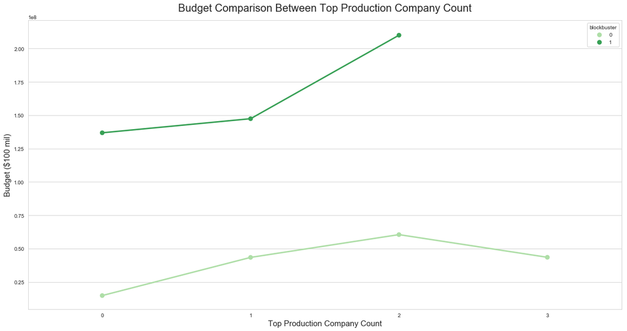

```python
sns.pointplot(x='top_prod_co',y='budget',hue='blockbuster',ci=None,palette='Greens',data=df_final);
plt.title('Budget Comparison Between Top Production Company Count', fontsize = 20, y = 1.02);
plt.ylabel('Budget ($100 mil)', fontsize = 15);
plt.xlabel('Top Production Company Count', fontsize = 15);
```

Here, we see that blockbusters have higher average budgets. We also see as the number of top production companies involved in a blockbuster's production increases, the budget for that blockbuster also increases. We are not certain that movies that are not blockbusters have higher budgets when additional top production companies are involved in production since the average budget increases when there are fewer than 2 top production companies involved and decreases when there are more than 2 top production companies involved.

### Regression Results & Analysis

In order to run our regression model more easily, we created a new dataframe with all the variables we wanted to include in our model. We moved revenue to the back of this new dataframe. We then built an ordinary least squares regression model using the statsmodels package.

```python
df_reg = df_final[['budget', 'popularity', 'runtime',
       'vote_average', 'vote_count', 'Western', 'Romance', 'Thriller',
       'Animation', 'Crime', 'Horror', 'TV Movie', 'Comedy', 'Mystery',
       'Music', 'War', 'Adventure', 'Science Fiction', 'Foreign', 'Fantasy',
       'Drama', 'History', 'Family', 'Documentary', 'Action', 'country_count',
       'top_prod_co', 'median_income', 'holiday_release',
       'superbowl_release', 'stanley_cup_release', 'nba_release',
       'world_series_release', 'population in thousands',
       'season', 'a_list_count', 'blockbuster_date', 'revenue']]
```

##### Export 3 for Showcase

```python
df_reg.to_excel('export3.xlsx')
```

```python
X = df_reg.iloc[:,0:-1]
s_df = pd.get_dummies(X.season,drop_first=True)
X = pd.concat([X,s_df],axis=1)
Y = df_reg.iloc[:,-1]
X = X.drop(['season'],axis=1)
```

```python
import statsmodels.api as sm
```

```python
model = sm.OLS(endog=Y, exog=X)
results = model.fit()
results.summary()
```

OLS Regression Results

| Dep. Variable: | revenue | R-squared: | 0.764 |
| --- | --- | --- | --- |
| Model: | OLS | Adj. R-squared: | 0.762 |
| Method: | Least Squares | F-statistic: | 368.0 |
| Date: | Sun, 12 May 2019 | Prob (F-statistic): | 0.00 |
| Time: | 00:07:52 | Log-Likelihood: | -88393. |
| No. Observations: | 4462 | AIC: | 1.769e+05 |
| Df Residuals: | 4423 | BIC: | 1.771e+05 |
| Df Model: | 39 |  |  |
| Covariance Type: | nonrobust |  |  |

|  | coef | std err | t | P>\|t\| | [0.025 | 0.975] |
| --- | --- | --- | --- | --- | --- | --- |
| budget | 1.1988 | 0.056 | 21.589 | 0.000 | 1.090 | 1.308 |
| popularity | 3.58e+04 | 7.24e+04 | 0.494 | 0.621 | -1.06e+05 | 1.78e+05 |
| runtime | 9.284e+04 | 8.56e+04 | 1.085 | 0.278 | -7.49e+04 | 2.61e+05 |
| vote_average | -1.416e+07 | 1.47e+06 | -9.660 | 0.000 | -1.7e+07 | -1.13e+07 |
| vote_count | 6.982e+04 | 2068.058 | 33.760 | 0.000 | 6.58e+04 | 7.39e+04 |
| Western | -2.899e+07 | 1.32e+07 | -2.203 | 0.028 | -5.48e+07 | -3.19e+06 |
| Romance | 4.683e+06 | 4.11e+06 | 1.140 | 0.254 | -3.37e+06 | 1.27e+07 |
| Thriller | -5.359e+06 | 4.11e+06 | -1.304 | 0.192 | -1.34e+07 | 2.7e+06 |
| Animation | 2.864e+07 | 8.29e+06 | 3.454 | 0.001 | 1.24e+07 | 4.49e+07 |
| Crime | -2.058e+07 | 4.61e+06 | -4.465 | 0.000 | -2.96e+07 | -1.15e+07 |
| Horror | 2.805e+06 | 5.49e+06 | 0.511 | 0.609 | -7.95e+06 | 1.36e+07 |
| TV Movie | 6.027e+07 | 3.7e+07 | 1.628 | 0.104 | -1.23e+07 | 1.33e+08 |
| Comedy | -3.511e+06 | 3.74e+06 | -0.940 | 0.347 | -1.08e+07 | 3.81e+06 |
| Mystery | -7.213e+06 | 5.96e+06 | -1.211 | 0.226 | -1.89e+07 | 4.47e+06 |
| Music | 6.96e+06 | 8.16e+06 | 0.852 | 0.394 | -9.05e+06 | 2.3e+07 |
| War | -1.894e+07 | 9.91e+06 | -1.912 | 0.056 | -3.84e+07 | 4.81e+05 |
| Adventure | 1.53e+07 | 4.87e+06 | 3.141 | 0.002 | 5.75e+06 | 2.49e+07 |
| Science Fiction | -3.516e+07 | 5.15e+06 | -6.824 | 0.000 | -4.53e+07 | -2.51e+07 |
| Foreign | 4.86e+07 | 1.72e+07 | 2.831 | 0.005 | 1.49e+07 | 8.23e+07 |
| Fantasy | -1.693e+06 | 5.53e+06 | -0.306 | 0.759 | -1.25e+07 | 9.15e+06 |
| Drama | -1.9e+06 | 3.77e+06 | -0.505 | 0.614 | -9.28e+06 | 5.48e+06 |
| History | -7.055e+06 | 8.57e+06 | -0.823 | 0.410 | -2.39e+07 | 9.75e+06 |
| Family | 1.34e+07 | 5.97e+06 | 2.245 | 0.025 | 1.7e+06 | 2.51e+07 |
| Documentary | 3.203e+07 | 1.04e+07 | 3.095 | 0.002 | 1.17e+07 | 5.23e+07 |
| Action | -9.656e+06 | 4.25e+06 | -2.269 | 0.023 | -1.8e+07 | -1.31e+06 |
| country_count | -6.346e+06 | 1.95e+06 | -3.256 | 0.001 | -1.02e+07 | -2.52e+06 |
| top_prod_co | -1.355e+07 | 3.12e+06 | -4.344 | 0.000 | -1.97e+07 | -7.43e+06 |
| median_income | -2704.9095 | 406.850 | -6.648 | 0.000 | -3502.539 | -1907.280 |
| holiday_release | 1.818e+06 | 3.55e+06 | 0.512 | 0.609 | -5.15e+06 | 8.78e+06 |
| superbowl_release | -4.665e+06 | 8.43e+06 | -0.553 | 0.580 | -2.12e+07 | 1.19e+07 |
| stanley_cup_release | 2.307e+07 | 8.57e+06 | 2.692 | 0.007 | 6.27e+06 | 3.99e+07 |
| nba_release | -5.557e+06 | 8.65e+06 | -0.642 | 0.521 | -2.25e+07 | 1.14e+07 |
| world_series_release | -4.51e+06 | 7.12e+06 | -0.634 | 0.526 | -1.85e+07 | 9.44e+06 |
| population in thousands | 838.2210 | 92.135 | 9.098 | 0.000 | 657.590 | 1018.852 |
| a_list_count | -6.103e+06 | 2.19e+06 | -2.787 | 0.005 | -1.04e+07 | -1.81e+06 |
| blockbuster_date | 4.094e+07 | 3.9e+06 | 10.511 | 0.000 | 3.33e+07 | 4.86e+07 |
| Spring | 7.319e+06 | 4.86e+06 | 1.505 | 0.132 | -2.22e+06 | 1.69e+07 |
| Summer | 3.41e+06 | 4.86e+06 | 0.701 | 0.483 | -6.12e+06 | 1.29e+07 |
| Winter | 9.301e+06 | 4.42e+06 | 2.102 | 0.036 | 6.27e+05 | 1.8e+07 |

| Omnibus: | 2752.941 | Durbin-Watson: | 1.607 |
| --- | --- | --- | --- |
| Prob(Omnibus): | 0.000 | Jarque-Bera (JB): | 142942.620 |
| Skew: | 2.258 | Prob(JB): | 0.00 |
| Kurtosis: | 30.358 | Cond. No. | 1.31e+09 |

Warnings:  
[1] Standard Errors assume that the covariance matrix of the errors is correctly specified.  
[2] The condition number is large, 1.31e+09. This might indicate that there are  
strong multicollinearity or other numerical problems.

Our regression model has an Adj. R-squared value of .762, indicating that it is a fairly decent model for predicting a movie's revenue. According to the regression output below, many variables are significant for affecting revenue in the movies dataset. The following variables are significant at the 5% significance level:

- Budget
- Vote average
- Vote count
- Western
- Animation
- Crime
- Adventure
- Science Fiction
- Foreign
- Family
- Documentary
- Action
- Country count
- Top production companies
- Median income
- Stanley Cup release
- Population in thousands
- A-list celebrities
- Blockbuster
- Winter

We wanted to see how the significant variables are related to revenue. The magnitude and direction of significant variables would decide if they are directly or inversely related to revenue. We did this by creating a dataframe of the coefficients and error terms of the significant variables produced from our regression above.

```python
err_series = results.params - results.conf_int()[0]
coef_df = pd.DataFrame({'name':results.params.index,'coeff':results.params.values,'err': err_series.values})
significant_variables = coef_df.iloc[[0,3,4,5,8,9,16,17,18,22,23,24,25,26,27,30,33,34,35,38],:]
significant_variables
```

|  | name | coeff | err |
| --- | --- | --- | --- |
| 0 | budget | 1.198781e+00 | 1.088609e-01 |
| 3 | vote_average | -1.416082e+07 | 2.873826e+06 |
| 4 | vote_count | 6.981751e+04 | 4.054429e+03 |
| 5 | Western | -2.898769e+07 | 2.579695e+07 |
| 8 | Animation | 2.864248e+07 | 1.625822e+07 |
| 9 | Crime | -2.057617e+07 | 9.035184e+06 |
| 16 | Adventure | 1.530255e+07 | 9.549787e+06 |
| 17 | Science Fiction | -3.515679e+07 | 1.010085e+07 |
| 18 | Foreign | 4.860331e+07 | 3.365821e+07 |
| 22 | Family | 1.339856e+07 | 1.169946e+07 |
| 23 | Documentary | 3.203440e+07 | 2.029216e+07 |
| 24 | Action | -9.656049e+06 | 8.341571e+06 |
| 25 | country_count | -6.346061e+06 | 3.821357e+06 |
| 26 | top_prod_co | -1.354509e+07 | 6.112441e+06 |
| 27 | median_income | -2.704910e+03 | 7.976292e+02 |
| 30 | stanley_cup_release | 2.306949e+07 | 1.679947e+07 |
| 33 | population in thousands | 8.382210e+02 | 1.806313e+02 |
| 34 | a_list_count | -6.102760e+06 | 4.293325e+06 |
| 35 | blockbuster_date | 4.094031e+07 | 7.636230e+06 |
| 38 | Winter | 9.301051e+06 | 8.673714e+06 |

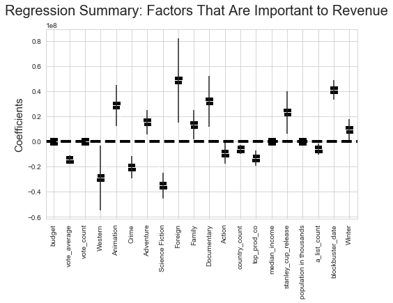

```python
fig, ax = plt.subplots(figsize=(8, 5))
fig.suptitle('Regression Summary: Factors That Are Important to Revenue', fontsize = 20)
significant_variables.plot(x='name', y='coeff', kind='bar', ax=ax, color='none', yerr='err', legend=False)
ax.set_ylabel('Coefficients', fontsize = 15)
ax.set_xlabel('')
ax.scatter(x=pd.np.arange(significant_variables.shape[0]),marker='s', s=120,y=significant_variables['coeff'], color='black')
ax.axhline(y=0, linestyle='--', color='black', linewidth=4)
ax.xaxis.set_ticks_position('none')
```

Vote average, country count, top production companies used in a movie's production, and the presence of A-List actors and actresses are inversely related to revenue. This means if any one of these variables is increased, on average, revenue should decrease, or vice versa. A movie's revenue will also decrease, on average, if it is classified as a western, crime, science fiction, or action film.

### Conclusion

We were able to gain many insights about what factors affect movie revenue using the data from the TMDB dataset. Using our visualizations, we were able to see insights such as whether a certain genre leads to higher average revenue, how average revenue can be affected by the season in which a movie is released, and how blockbuster films require additional budget spending.

The regression model has an adjusted R square of 0.762, meaning the model did pretty well in predicting movies' revenue. Many of the variables we created using the external information are also quite significant in predicting movies’ revenue based on p-value at a 5% significance level. These results indicate that our model and insights are reliable and accurate.

Movie production companies need to be able to determine what will make their movies successful. One key performance indicator is revenue. Our model provides trustworthy inferential and prediction information. Production companies can use our analysis to remove some of the risk when making the decision to invest in a new movie.